# Exercise 11 - Caravans

## 0. Setup

Load packages.

```r
library(tidyverse)
library(tidymodels)
library(caret)
library(ISLR)
library(GGally)
```

## Caravan data

Save Caravan data as a tibble.

```r
caravan_df %>%
  map(unique)
```

```
$MOSTYPE
 [1] 33 37  9 40 23 39 11 10 41 38 22 13 31 34 24  8  7  3 36 25 20 12 35 30 29 32  1 26  2  4 16  5 21  6 18 27 28 17
[39] 15 19

$MAANTHUI
[1]  1  2  3 10  5  7  4  8  6

$MGEMOMV
[1] 3 2 4 1 5

$MGEMLEEF
[1] 2 3 1 4 5 6

$MOSHOOFD
 [1]  8  3 10  5  9  7  2  1  6  4

$MGODRK
 [1] 0 1 2 3 4 6 5 9 7 8

$MGODPR
 [1] 5 4 3 2 7 1 6 9 0 8

$MGODOV
[1] 1 2 0 3 4 5

$MGODGE
 [1] 3 4 5 2 6 7 0 1 9 8

$MRELGE
 [1] 7 6 3 5 0 1 9 8 2 4

$MRELSA
[1] 0 2 1 6 4 3 5 7

$MRELOV
 [1] 2 4 3 0 1 6 5 7 8 9

$MFALLEEN
 [1] 1 0 4 2 3 5 6 7 8 9

```

[output cut: 215 more lines]

```

$AFIETS
[1] 0 1 2 3

$AINBOED
[1] 0 1 2
Levels: 0 1 2

$ABYSTAND
[1] 0 1 2
Levels: 0 1 2

$Purchase
[1] No  Yes
Levels: No Yes
```

# EDA

Plot charts of variables vs response variable.

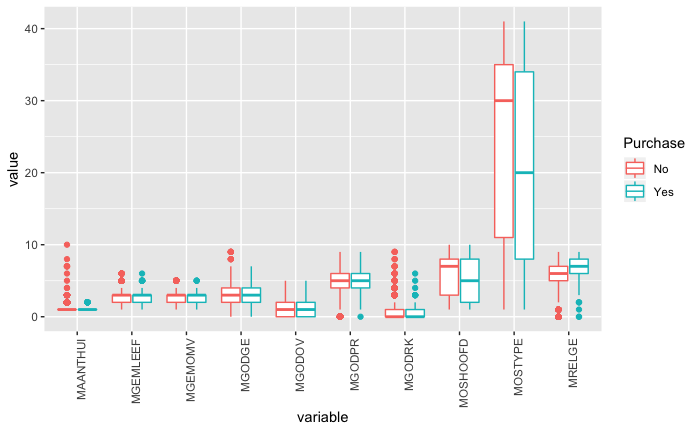

```r
# First 10 variables
caravan_df %>%
  select(1:10, "Purchase") %>%
  gather(1:10, key = "variable", value = "value") %>%
  ggplot(aes(variable, value, colour = Purchase)) +
  geom_boxplot() +
  theme(axis.text.x = element_text(angle = 90, hjust = 1))
```

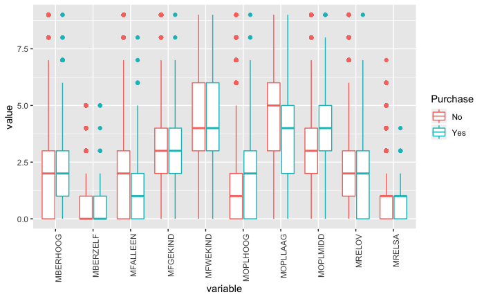

```r
# 11 to 20 variables (10)
caravan_df %>%
  select(11:20, "Purchase") %>%
  gather(1:10, key = "variable", value = "value") %>%
  ggplot(aes(variable, value, colour = Purchase)) +
  geom_boxplot() +
  theme(axis.text.x = element_text(angle = 90, hjust = 1))
```

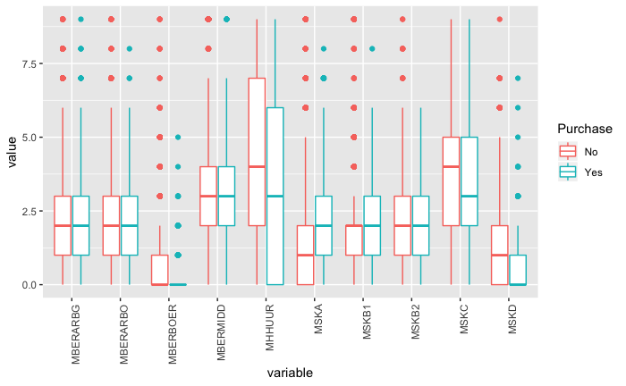

```r
# 20
caravan_df %>%
  select(21:30, "Purchase") %>%
  gather(1:10, key = "variable", value = "value") %>%
  ggplot(aes(variable, value, colour = Purchase)) +
  geom_boxplot() +
  theme(axis.text.x = element_text(angle = 90, hjust = 1))
```

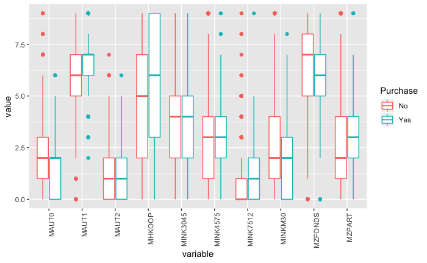

```r
# 30
caravan_df %>%
  select(31:40, "Purchase") %>%
  gather(1:10, key = "variable", value = "value") %>%
  ggplot(aes(variable, value, colour = Purchase)) +
  geom_boxplot() +
  theme(axis.text.x = element_text(angle = 90, hjust = 1))
```

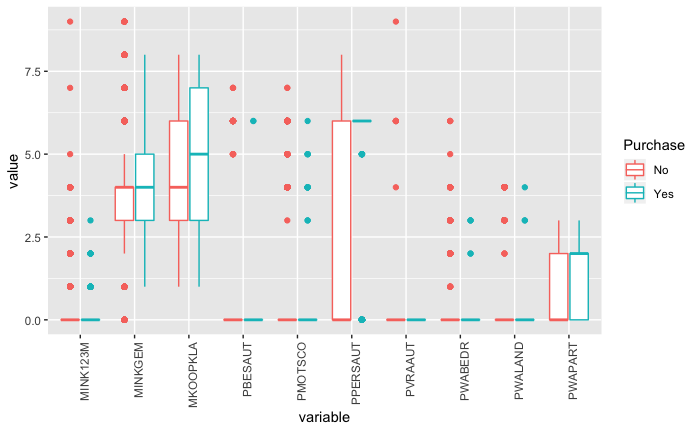

```r
# 40
caravan_df %>%
  select(41:50, "Purchase") %>%
  gather(1:10, key = "variable", value = "value") %>%
  ggplot(aes(variable, value, colour = Purchase)) +
  geom_boxplot() +
  theme(axis.text.x = element_text(angle = 90, hjust = 1))
```

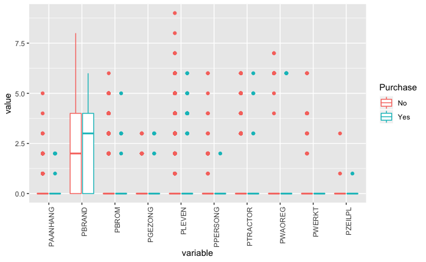

```r
# 50
caravan_df %>%
  select(51:60, "Purchase") %>%
  gather(1:10, key = "variable", value = "value") %>%
  ggplot(aes(variable, value, colour = Purchase)) +
  geom_boxplot() +
  theme(axis.text.x = element_text(angle = 90, hjust = 1))
```

```
attributes are not identical across measure variables;
they will be dropped
```

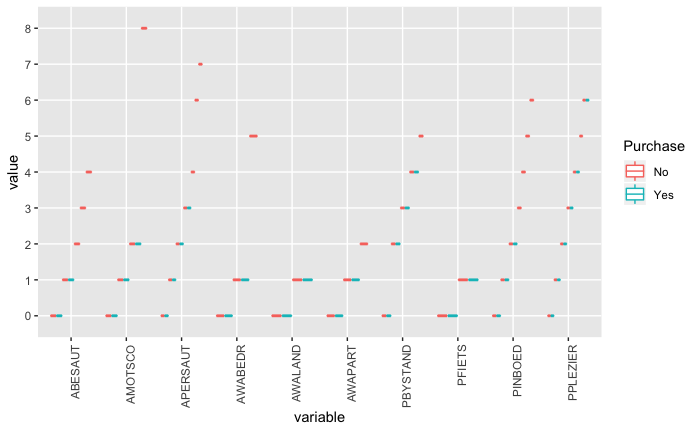

```r
# 60
caravan_df %>%
  select(61:70, "Purchase") %>%
  gather(1:10, key = "variable", value = "value") %>%
  ggplot(aes(variable, value, colour = Purchase)) +
  geom_boxplot() +
  theme(axis.text.x = element_text(angle = 90, hjust = 1))
```

```
attributes are not identical across measure variables;
they will be dropped
```

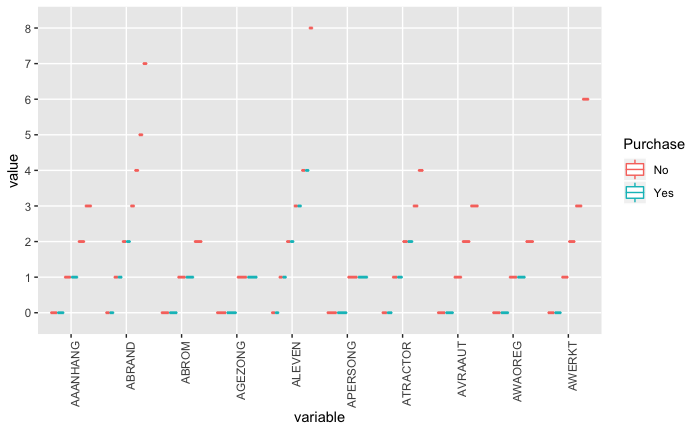

```r
# 70
caravan_df %>%
  select(71:80, "Purchase") %>%
  gather(1:10, key = "variable", value = "value") %>%
  ggplot(aes(variable, value, colour = Purchase)) +
  geom_boxplot() +
  theme(axis.text.x = element_text(angle = 90, hjust = 1))
```

```
attributes are not identical across measure variables;
they will be dropped
```

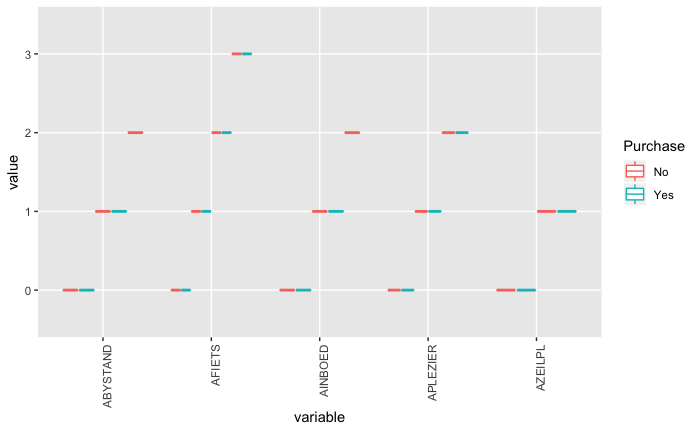

```r
# 80
caravan_df %>%
  select(81:85, "Purchase") %>%
  gather(1:5, key = "variable", value = "value") %>%
  ggplot(aes(variable, value, colour = Purchase)) +
  geom_boxplot() +
  theme(axis.text.x = element_text(angle = 90, hjust = 1))
```

For variables 50 onwards most of the variable values are zero and so the boxplot is mostly a line at 0 with dots for outliers that are not zero. Do bar charts for these variables instead. Filter out zero values as distort comparison of charts and differences in density of zeros will show up in density of non-zero values anyway.

```r
# 41 to 50 (40)
caravan_df %>%
  select(41:50, "Purchase") %>%
  gather(1:10, key = "variable", value = "value") %>%
  filter(round(value, 4) != 0) %>%
  ggplot(aes(value, fill = Purchase)) +
  geom_histogram(aes(y = stat(width*density)), position = "dodge") +
  facet_wrap(~ variable) +
  theme(axis.text.x = element_text(angle = 90, hjust = 1))

# 50
caravan_df %>%
  select(51:60, "Purchase") %>%
  gather(1:10, key = "variable", value = "value") %>%
  filter(round(value, 4) != 0) %>%
  ggplot(aes(value, fill = Purchase)) +
  geom_histogram(aes(y = stat(width*density)), position = "dodge") +
  facet_wrap(~ variable) +
  theme(axis.text.x = element_text(angle = 90, hjust = 1))

# 60
caravan_df %>%
  select(61:70, "Purchase") %>%
  gather(1:10, key = "variable", value = "value") %>%
  filter(round(value, 4) != 0) %>%
  ggplot(aes(value, fill = Purchase)) +
  geom_histogram(aes(y = stat(width*density)), position = "dodge") +
  facet_wrap(~ variable) +
  theme(axis.text.x = element_text(angle = 90, hjust = 1))

# 70
caravan_df %>%
  select(71:80, "Purchase") %>%
  gather(1:10, key = "variable", value = "value") %>%
  filter(round(value, 4) != 0) %>%
  ggplot(aes(value, fill = Purchase)) +
  geom_histogram(aes(y = stat(width*density)), position = "dodge") +
  facet_wrap(~ variable) +
  theme(axis.text.x = element_text(angle = 90, hjust = 1))

# 81 to 85
caravan_df %>%
  select(81:85, "Purchase") %>%
  gather(1:5, key = "variable", value = "value") %>%
  filter(round(value, 4) != 0) %>%
  ggplot(aes(value, fill = Purchase)) +
  geom_histogram(aes(y = stat(width*density)), position = "dodge") +
  facet_wrap(~ variable) +
  theme(axis.text.x = element_text(angle = 90, hjust = 1))
```

[output not shown]

From variables 41 to 85, the followin appear to differentiate between Purchase = Yes and Purchase = No the best: PBESAUT, PVRAAUT, PWABEDR, PWERKT, AVRAAUT, AWERKT, PPERSONG, PGEZONG, PZEILPL.

Select the variables from 1 to 40 which appear to have the best predictive power and check to see if any correlations between these variables.

```r
vars_spread <-
  c(
    "MRELGE",
    "MOPLMIDD",
    "MHHUUR",
    "MSKA",
    "MOSHOOFD",
    "MOSTYPE",
    "MHKOOP",
    "MZFONDS",
    "PWAPART"
  )

# Correlation matrix
caravan_df %>%
  select(one_of(vars_spread)) %>%
  ggcorr(nbreaks=8, palette='RdGy', label=TRUE, label_size=5, label_color='white')
```

[output not shown]

There is a clear correlation between MOSHOOFD and MOSTYPE. It looks like MOSTYPE is a subcategory of MOSHOOFD. Only include MOSTYPE as this includes more information (wider range of values).

```r
# Investigate pairs of variables wih high correlations further.
my_bin <-
  function(data,
           mapping,
           ...,
           low = "#132B43",
           high = "#56B1F7") {
    ggplot(data = data, mapping = mapping) +
      geom_bin2d(...) +
      scale_fill_gradient(low = low, high = high)
  }

caravan_df %>%
  select(one_of(c("MOSHOOFD", "MOSTYPE", "MZFONDS", "MHKOOP")), "Purchase") %>%
  ggpairs(columns = 1:4, lower = list(continuous = wrap(
    my_bin, binwidth = c(0.5, 0.5), high = "red"
  )))
```

[output not shown]

Repeat for variables 41 to 85

```
Unknown columns: `BESAUT`
```

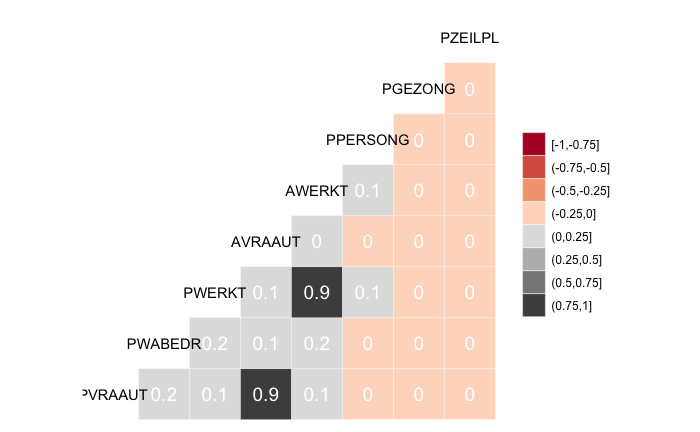

```r
vars_spread_2 <-
  c(
    "BESAUT",
    "PVRAAUT",
    "PWABEDR",
    "PWERKT",
    "AVRAAUT",
    "AWERKT",
    "PPERSONG",
    "PGEZONG",
    "PZEILPL"
  )

# Correlation matrix
caravan_df %>%
  select(one_of(vars_spread_2)) %>%
  ggcorr(nbreaks=8, palette='RdGy', label=TRUE, label_size=5, label_color='white')
```

Investigate pairs AWERKT & PWERKT, and AVRAAUT & PVRAAUT further as have high positive high correlations.